# Words that (might) matter, or keywords extraction methods

Maciej Eder (maciej.eder@ijp.pan.pl)

27.02.2023 Using and Developing Software for Keyness Analysis University of Trier, 27–28.02.2023

## Motivation

- Information retrieval:
  - How to “read” a big collection of documents, e.g. an archive?
- Linguistics:
  - What is the underlying model for defining word meaning?

## Does an ideal keyword exist?

- information retrieval:
  - “meaningful” words
  - what a given text is about
- stylometry:
  - is the stylistic layer also important?
  - if a given author/genre overuses the word “the”, should that be captured? neglected?

## Basic assumptions

- Words are unevenly distributed in two text collections.
- Distribution of a word in text corpora will *always* differ.
- The real problem is to identify differences that are *significant*.
- Keyword = a word significantly more frequent in a given text.

## A simple idea…

I have just returned from a visit to my landlord – the solitary neighbour that I shall be troubled with.

neighbour solitary troubled landlord visit returned just shall from I have be with my that a to the

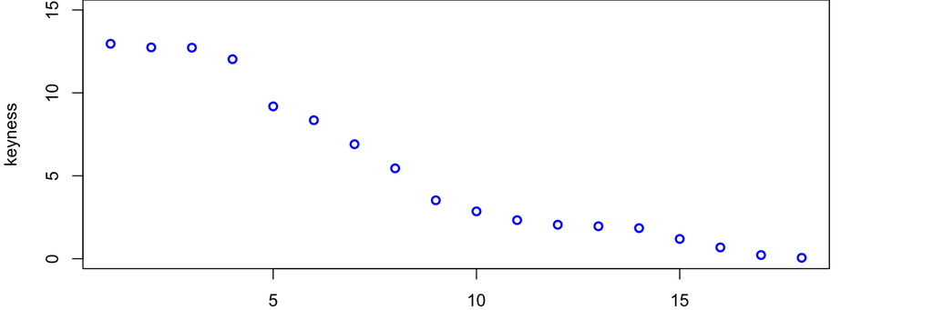

## Bronte, *The Wuthering Heights*

heathcliff, linton, catherine, hareton, earnshaw, cathy, edgar, ellen, heights, hindley, nelly, ll, grange, i, wuthering, t, joseph, isabella, master, gimmerton, zillah, m, exclaimed, he, thrushcross, and, answered, yah, kenneth, ve, maister, lockwood, kitchen, you, dean, moors, replied, cried, him, muttered, lintons, papa, she, till, commenced, on, wer, ech, shoo, leant, hearth, bonny, door, stairs, hell, me, crags, moor, wouldn, fiend, settle, jabez, penistone, fire, ye, its, bid, nowt, naught, yer, hush, mistress, grew, lad, compelled, minny, won, hisseln, skulker, soa, wisht, cousin, lattice, didn, yon, minute, lass, needn, inquired, snow, branderham, flaysome, gooid, sud, thear, affirming, interrupted, couldn, window, …, …, …, **a, in, the**

## Frequencies?

## Frequencies in two texts

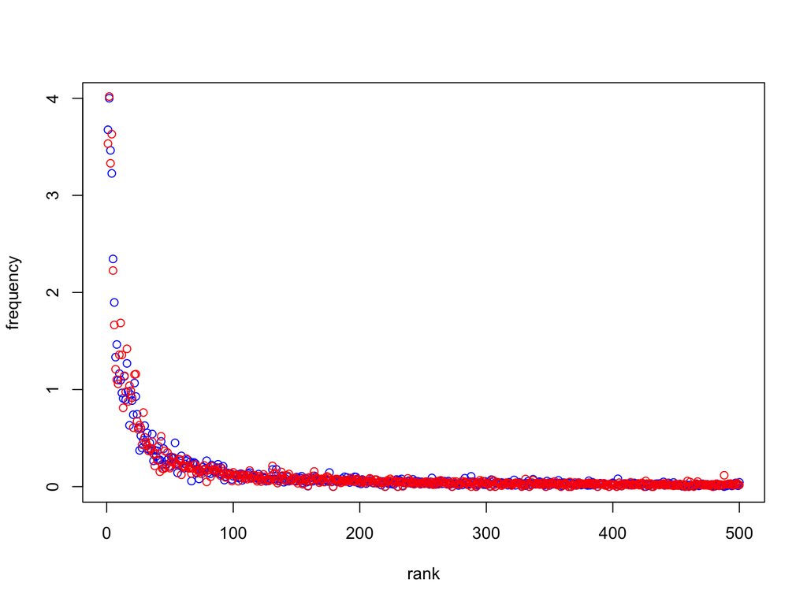

## Differences between frequencies

| the | and | to | i | of | … |
| --- | --- | --- | --- | --- | --- |
| 3.557 | 2.938 | 3.398 | 1.696 | 2.965 | … |
| 3.919 | 4.068 | 2.988 | 3.078 | 1.905 | … |

the difference between the values:

| the | and | to | i | of | … |
| --- | --- | --- | --- | --- | --- |
| -0.362 | -1.130 | 0.410 | -1.382 | 1.059 | … |

## Differences between frequencies

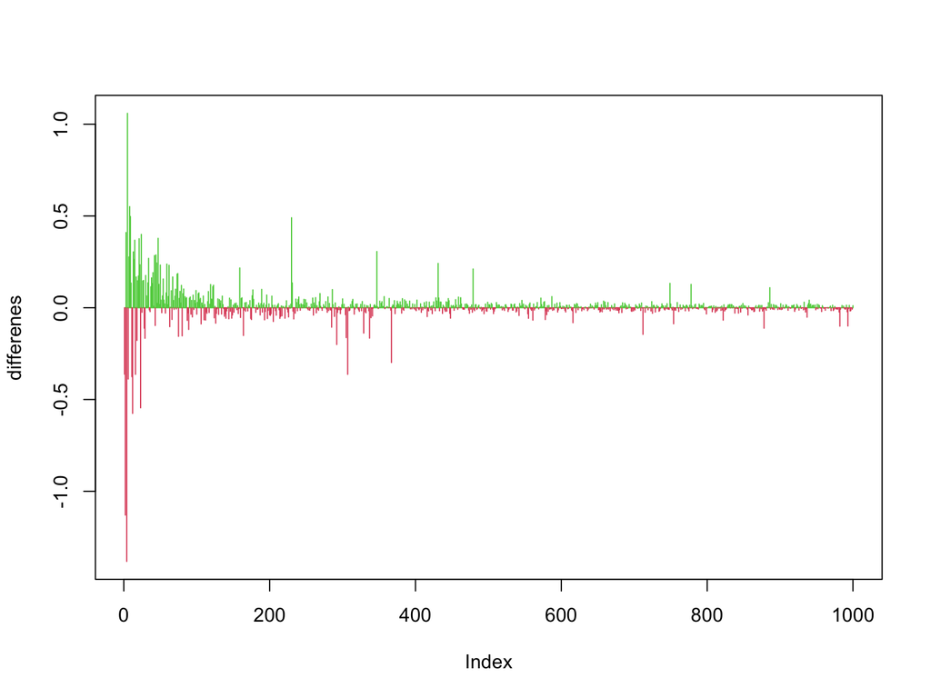

## The most distinctive words

```
##   [1] "of"          "was"         "her"         "elizabeth"   "to"
##   [6] "be"          "mr"          "had"         "not"         "darcy"
##  [11] "she"         "very"        "which"       "in"          "all"
##  [16] "that"        "they"        "bennet"      "their"       "but"
##  [21] "been"        "such"        "jane"        "bingley"     "could"
##  [26] "much"        "am"          "so"          "with"        "mrs"
##  [31] "as"          "were"        "them"        "have"        "for"
##  [36] "is"          "by"          "sister"      "it"          "wickham"
##  [41] "what"        "will"        "collins"     "herself"     "most"
##  [46] "miss"        "soon"        "this"        "lydia"       "who"
##  [51] "any"         "dear"        "family"      "lady"        "every"
##  [56] "must"        "know"        "without"     "though"      "more"
##  [61] "letter"      "lizzy"       "other"       "think"       "longbourn"
##  [66] "many"        "good"        "gardiner"    "mother"      "do"
##  [71] "no"          "may"         "great"       "hope"        "well"
##  [76] "than"        "ladies"      "sisters"     "time"        "netherfield"
##  [81] "manner"      "friend"      "can"         "aunt"        "kitty"
##  [86] "charlotte"   "feelings"    "daughter"    "before"      "however"
##  [91] "opinion"     "colonel"     "lucas"       "whom"        "marriage"
##  [96] "always"      "might"       "nothing"     "indeed"      "happiness"
```

## Keywords LL

## Keywords analysis

- log likelihood used to capture the differences
- implementation: AntConc, WordSmith Tools, etc.

## Keywords analysis

```
##   [1] "elizabeth"     "darcy"         "bennet"        "jane"
##   [5] "bingley"       "of"            "wickham"       "collins"
##   [9] "very"          "mr"            "lydia"         "which"
##  [13] "such"          "sister"        "was"           "their"
##  [17] "lizzy"         "much"          "am"            "longbourn"
##  [21] "be"            "all"           "gardiner"      "had"
##  [25] "been"          "most"          "ladies"        "netherfield"
##  [29] "they"          "kitty"         "her"           "charlotte"
##  [33] "colonel"       "lucas"         "mrs"           "sisters"
##  [37] "dear"          "family"        "not"           "herself"
##  [41] "meryton"       "opinion"       "marriage"      "pemberley"
##  [45] "letter"        "soon"          "daughters"     "aunt"
##  [49] "bingley^s"     "rosings"       "town"          "could"
##  [53] "darcy^s"       "lady"          "party"         "hertfordshire"
##  [57] "daughter"      "them"          "de"            "william"
##  [61] "girls"         "miss"          "elizabeth^s"   "forster"
##  [65] "lydia^s"       "happiness"     "without"       "many"
##  [69] "bourgh"        "mother"        "so"            "every"
##  [73] "but"           "gentlemen"     "general"       "known"
##  [77] "feelings"      "she"           "therefore"     "sister^s"
##  [81] "london"        "hurst"         "wickham^s"     "officers"
##  [85] "fitzwilliam"   "were"          "whom"          "manner"
##  [89] "ladyship"      "bennet^s"      "civility"      "friend"
##  [93] "ball"          "mary"          "jane^s"        "hope"
##  [97] "certainly"     "will"          "any"           "that"
```

## Zeta

## Zeta: the background

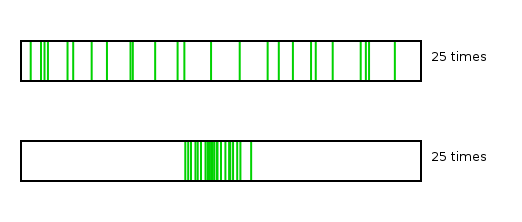

## Zeta: the solution

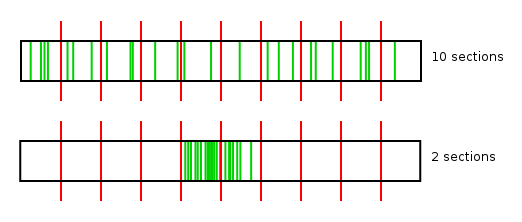

$$\zeta_{(a,b)} = \left(\frac{f_a -
f_b}{100}\right) +1$$

(Burrows, 2007; Craig, 2009)

## Zeta: outcomes

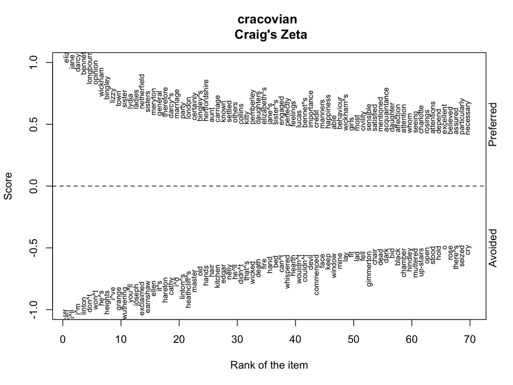

## Zeta’s words

```
##   [1] "elizabeth"     "jane"          "darcy"         "bennet"
##   [5] "longbourn"     "opinion"       "wickham"       "bingley"
##   [9] "lizzy"         "town"          "sister"        "lydia"
##  [13] "ladies"        "netherfield"   "sisters"       "meryton"
##  [17] "general"       "therefore"     "darcy^s"       "marriage"
##  [21] "party"         "london"        "certainly"     "bingley^s"
##  [25] "hertfordshire" "aunt"          "carriage"      "known"
##  [29] "settled"       "others"        "collins"       "kitty"
##  [33] "pemberley"     "daughters"     "elizabeth^s"   "jane^s"
##  [37] "sister^s"      "engaged"       "perfectly"     "feelings"
##  [41] "lucas"         "bennet^s"      "importance"    "credit"
##  [45] "manners"       "happiness"     "able"          "behaviour"
##  [49] "wickham^s"     "girls"         "most"          "civility"
##  [53] "sensible"      "satisfied"     "mentioned"     "acquaintance"
##  [57] "daughter"      "affection"     "attention"     "whom"
##  [61] "seeing"        "charlotte"     "rosings"       "attentions"
##  [65] "depend"        "excellent"     "believed"      "assured"
##  [69] "particularly"  "necessary"     "regard"        "likely"
##  [73] "conversation"  "colonel"       "many"          "added"
##  [77] "praise"        "understanding" "mary"          "highly"
##  [81] "anyone"        "address"       "concern"       "fortune"
##  [85] "assure"        "agreeable"     "honour"        "consequence"
##  [89] "given"         "possible"      "mother"        "gardiner"
##  [93] "de"            "lydia^s"       "bourgh"        "gentlemen"
##  [97] "pleasing"      "eldest"        "particulars"   "subject"
```

## TF–IDF

## TF–IDF

- Term frequency x inversed document frequency
- IDF: a weighting factor to boost **important** frequencies
- important being the ones that appear in few texts and yet, are frequent

$$TFIDF_{w} = f_{w} \times \log
\frac{N}{n_{t}}$$

## TF–IDF’s words

```
##   [1] "darcy"         "bennet"        "bingley"       "elizabeth"
##   [5] "wickham"       "collins"       "lydia"         "longbourn"
##   [9] "gardiner"      "netherfield"   "lucas"         "lizzy"
##  [13] "meryton"       "pemberley"     "bingley^s"     "rosings"
##  [17] "kitty"         "darcy^s"       "hertfordshire" "elizabeth^s"
##  [21] "forster"       "lydia^s"       "bourgh"        "wickham^s"
##  [25] "fitzwilliam"   "jane"          "catherine"     "bennet^s"
##  [29] "phillips"      "hunsford"      "brighton"      "collins^s"
##  [33] "derbyshire"    "hurst"         "charlotte"     "colonel"
##  [37] "officers"      "william"       "kent"          "lucases"
##  [41] "gardiner^s"    "denny"         "charlotte^s"   "ladyship"
##  [45] "judgement"     "catherine^s"   "de"            "jane^s"
##  [49] "bennets"       "lambton"       "reynolds"      "maria"
##  [53] "gracechurch"   "etc"           "anyone"        "ladyship^s"
##  [57] "eliza"         "jenkinson"     "parsonage"     "elopement"
##  [61] "behaviour"     "georgiana"     "gardiners"     "entail"
##  [65] "caroline"      "regiment"      "bingleys"      "collinses"
##  [69] "enumerating"   "fitzwilliam^s" "lucas^s"       "phillips^s"
##  [73] "cousin"        "saturday"      "shire"         "militia"
##  [77] "corps"         "james^s"       "lakes"         "bourgh^s"
##  [81] "clapham"       "fishing"       "newcastle"     "younge"
##  [85] "ladies"        "niece"         "exposing"      "felicity"
##  [89] "imprudence"    "uncommonly"    "assembly"      "wednesday"
##  [93] "nieces"        "engagements"   "louisa"        "twelvemonth"
##  [97] "gratifying"    "william^s"     "annesley"      "caroline^s"
```

## A new method

## An ideal measure

1. will automatically extract meaningful words for a text A and B
   - by “automatically” we mean that the technique will be unsupervised
   - by “meaningful” we mean that an extracted keyword brings much semantic information about a given subset of texts.
2. will be able to distinguish if the texts to be compared differ substantially, or only marginally.
3. will not require any computation-intense algorithms;
4. will be conceptually simple;
5. will have an intuitive linguistic interpretation;

## An ideal measure (cont.)

6. will not make any statistical assumptions, i.e. will be non-parametric;
7. will allow for significance testing of the identified keywords;
8. will not require any hyperparameters, or at least any arbitrarily chosen hyperparameters;
9. will correct for frequent words.

## A new measure

- Given the above constrains, we propose a simple measure of keyness that relies on:
  1. words’ frequencies,
  2. words’ positions on a frequency list.
- Since (2) is directly derivable from (1), the only thing that the measure requires is two lists of word frequencies.
- Mathematically, then, the only assumption we formulate is that there exist two texts of a finite length of $\lambda \in \mathbb{N}$.

[figure not shown]

## Shakespeare vs. Conan Doyle

| word | count | word | count |
| --- | --- | --- | --- |
| the | 27595 | the | 28662 |
| and | 26735 | and | 14109 |
| I | 22538 | of | 13229 |
| … | … | … | … |
| northerly | 1 | revolvers | 1 |

## Frequency **and** position

$$P_{r(x)} =
\frac{1}{N}\sum_{i=1}^{r(x)}f(i)$$

which also guarantees that the values are scaled into the range {0, 1}.

## Frequency **and** position

a simpler and more elegant version of the above:

$$P_{r(x)} = \left(
\frac{1}{N}\sum_{i=1}^{r(x)}f(x_{i}) \right) - f(x)$$

which is of course equal to:

$$P_{r(x)} =
\frac{1}{N}\sum_{i=1}^{r(x-1)}f(x_{i})$$

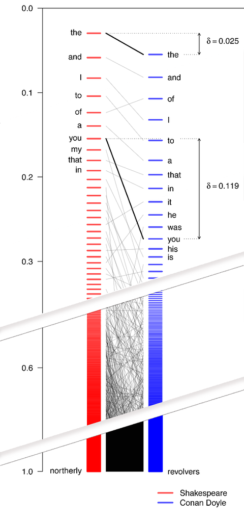

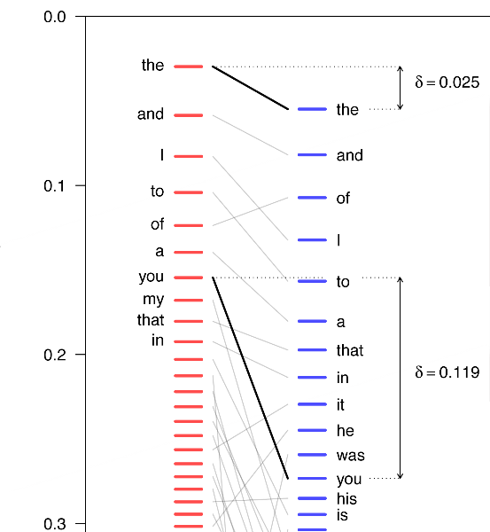

## The cracovian

Having normalized the frequencies/positions of the words, one can easily compute the distance between the same word between two sets (texts or subcorpora), say A and B, by simply estimating their difference. This can be defined as

$$\delta_{x,AB} = \| P_{r(x),A} -
P_{r(x),B} \|$$

## Cumulative sums

The above geometric interpretation can be also solved algebraically. In this interpretation, the position $P_{r(x)}$ of a given word is **simply a cumulative sum of frequencies of all the preceding words**.

## The words

```
##   [1] "elizabeth"     "darcy"         "bennet"        "jane"
##   [5] "bingley"       "wickham"       "collins"       "lydia"
##   [9] "lizzy"         "longbourn"     "gardiner"      "ladies"
##  [13] "netherfield"   "kitty"         "charlotte"     "colonel"
##  [17] "lucas"         "sisters"       "meryton"       "pemberley"
##  [21] "daughters"     "bingley^s"     "rosings"       "opinion"
##  [25] "darcy^s"       "marriage"      "hertfordshire" "de"
##  [29] "william"       "elizabeth^s"   "forster"       "lydia^s"
##  [33] "girls"         "bourgh"        "town"          "sister^s"
##  [37] "gentlemen"     "sister"        "hurst"         "wickham^s"
##  [41] "fitzwilliam"   "officers"      "ladyship"      "bennet^s"
##  [45] "party"         "jane^s"        "attentions"    "phillips"
##  [49] "ball"          "hunsford"      "brighton"      "collins^s"
##  [53] "derbyshire"    "mary"          "aunt"          "importance"
##  [57] "depend"        "eliza"         "pleasing"      "eldest"
##  [61] "general"       "match"         "particulars"   "understanding"
##  [65] "civility"      "compliment"    "praise"        "niece"
##  [69] "regiment"      "concerned"     "connections"   "felicity"
##  [73] "maria"         "charlotte^s"   "known"         "parsonage"
##  [77] "saturday"      "street"        "highly"        "dearest"
##  [81] "daughter"      "london"        "scheme"        "favour"
##  [85] "happiness"     "dancing"       "fortune"       "engagement"
##  [89] "prevailed"     "resentment"    "caroline"      "relations"
##  [93] "partner"       "kent"          "pounds"        "lucases"
##  [97] "occurred"      "excellent"     "etc"           "gardiner^s"
```

## Similar yet not identical

```
##        freqs         zeta            tfidf           cracovian
##   [1,] "of"          "elizabeth"     "darcy"         "elizabeth"
##   [2,] "was"         "jane"          "bennet"        "darcy"
##   [3,] "her"         "darcy"         "bingley"       "bennet"
##   [4,] "elizabeth"   "bennet"        "elizabeth"     "jane"
##   [5,] "to"          "longbourn"     "wickham"       "bingley"
##   [6,] "be"          "opinion"       "collins"       "wickham"
##   [7,] "mr"          "wickham"       "lydia"         "collins"
##   [8,] "had"         "bingley"       "longbourn"     "lydia"
##   [9,] "not"         "lizzy"         "gardiner"      "lizzy"
##  [10,] "darcy"       "town"          "netherfield"   "longbourn"
##  [11,] "she"         "sister"        "lucas"         "gardiner"
##  [12,] "very"        "lydia"         "lizzy"         "ladies"
##  [13,] "which"       "ladies"        "meryton"       "netherfield"
##  [14,] "in"          "netherfield"   "pemberley"     "kitty"
```

[output cut: 86 more lines]

## Comparison

## Gender keywords (19th century)

- 12 novels by female authors
  - Anne Bronte, Jane Austen, Charlotte Bronte, Emily Bronte, George Eliot
- 12 novels by male authors
  - Charles Dickens, Henry Fielding, Samuel Richardson, William Thackeray, Anthony Trollope
- A comparison of keywords returned by:
  - LL keywords analysis methdod
  - Cracovian
  - Zeta

## LL keywords

- female (?)

```
##  [1] "maggie"     "adam"       "lydgate"    "dorothea"   "emma"
##  [6] "lucy"       "hetty"      "elinor"     "tulliver"   "jane"
## [11] "elizabeth"  "casaubon"   "bulstrode"  "rosamond"   "marianne"
## [16] "weston"     "fred"       "dinah"      "catherine"  "heathcliff"
## [21] "was"        "darcy"      "tom"        "poyser"     "harriet"
## [26] "philip"     "felt"       "seemed"     "knightley"  "brooke"
## [31] "its"        "fairfax"    "linton"     "glegg"      "elton"
```

- male (?)

```
##  [1] "upon"      "lady"      "thou"      "lovelace"  "jones"     "phineas"
##  [7] "my"        "pen"       "lord"      "dear"      "sir"       "major"
## [13] "letter"    "howe"      "laura"     "harlowe"   "honour"    "madam"
## [19] "duke"      "george"    "that"      "belford"   "crawley"   "pendennis"
## [25] "sophia"    "clarissa"  "lopez"     "micawber"  "pamela"    "b"
## [31] "finn"      "so"        "peggotty"  "your"      "captain"
```

## Cracovian

- female (?)

```
##  [1] "maggie"      "lydgate"     "adam"        "dorothea"    "hetty"
##  [6] "lucy"        "elinor"      "tulliver"    "casaubon"    "rosamond"
## [11] "bulstrode"   "marianne"    "weston"      "emma"        "dinah"
## [16] "elizabeth"   "heathcliff"  "darcy"       "poyser"      "catherine"
## [21] "fred"        "knightley"   "brooke"      "philip"      "fairfax"
## [26] "glegg"       "elton"       "linton"      "graham"      "bennet"
## [31] "seth"        "garth"       "harriet"     "middlemarch" "ladislaw"
```

- male (?)

```
##  [1] "lovelace"    "phineas"     "jones"       "major"       "howe"
##  [6] "harlowe"     "belford"     "crawley"     "pendennis"   "clarissa"
## [11] "lopez"       "micawber"    "sophia"      "pamela"      "laura"
## [16] "finn"        "peggotty"    "duke"        "allworthy"   "thou"
## [21] "amelia"      "clavering"   "osborne"     "copperfield" "pen"
## [26] "wharton"     "traddles"    "bounderby"   "dobbin"      "rawdon"
## [31] "solmes"      "b"           "jarndyce"    "dora"        "eleanor"
```

## Zeta

- women are from Venus…

```
##  [1] "felt"      "feelings"  "feel"      "feeling"   "tone"      "seemed"
##  [7] "sense"     "rose"      "chapter"   "quiet"     "oh"        "minutes"
## [13] "cold"      "glance"    "yes"       "deep"      "entered"   "silence"
## [19] "looked"    "added"     "its"       "smile"     "turned"    "something"
## [25] "seated"    "scarcely"  "speaking"  "suddenly"  "longer"    "strong"
## [31] "i^ve"      "paused"    "towards"   "continued"
```

- …and men are from Mars

```
##  [1] "honour"    "lord"      "favour"    "although"  "friend"    "lady"
##  [7] "dear"      "letter"    "upon"      "dearest"   "honest"    "gentleman"
## [13] "lovelace"  "occasion"  "sir"       "sex"       "letters"   "london"
## [19] "harlowe"   "worthy"    "whom"      "story"     "therefore" "pen"
## [25] "thou"      "madam"     "creature"  "tis"       "wretch"    "beloved"
## [31] "clarissa"  "howe"      "written"   "write"
```

## Conclusions

## Conclusions

- Keywords are **all the words** ordered from the most to the least relevant.
- For a given text, the extracted keywords **depend on the method** used.
- **No cut-off point** between keywords and “ordinary” words.
- The new method (the Cracovian) **competitive yet simpler** than the time-proven solutions.
- In real-life applications, the method **Zeta seems to outperform** other techniques…
- …but systematic evaluation is needed to scrutinize this observation.

## Thank you!

- maciej.eder@ijp.pan.pl
- [@MaciejEder](https://twitter.com/MaciejEder)
- https://github.com/computationalstylistics

## Appendix

## Intersection of the two sets

```
##   [1] "sisters"       "opinion"       "marriage"      "girls"
##   [5] "town"          "sister^s"      "sister"        "party"
##   [9] "ball"          "mary"          "aunt"          "general"
##  [13] "match"         "understanding" "civility"      "compliment"
##  [17] "praise"        "known"         "street"        "highly"
##  [21] "daughter"      "london"        "scheme"        "favour"
##  [25] "happiness"     "dancing"       "fortune"       "engagement"
##  [29] "resentment"    "relations"     "partner"       "pounds"
##  [33] "excellent"     "evident"       "invitation"    "letter"
##  [37] "wholly"        "anyone"        "settled"       "sensible"
##  [41] "women"         "extraordinary" "therefore"     "agreeable"
##  [45] "madam"         "tuesday"       "possibility"   "fortunate"
##  [49] "credit"        "endeavour"     "dear"          "most"
##  [53] "success"       "concern"       "others"        "family"
##  [57] "grateful"      "assure"        "belief"        "engaged"
##  [61] "carriage"      "gratitude"     "terms"         "honour"
##  [65] "virtue"        "enjoyment"     "advantage"     "unlucky"
##  [69] "feelings"      "acknowledged"  "tolerable"     "inquiries"
##  [73] "such"          "motive"        "objections"    "likewise"
##  [77] "expectation"   "noble"         "moments"       "attended"
##  [81] "whom"          "address"       "manners"       "satisfied"
##  [85] "degree"        "valuable"      "remarkably"    "believed"
##  [89] "assured"       "very"          "uncle^s"       "respect"
##  [93] "thousand"      "situation"     "overcome"      "drawing-room"
##  [97] "visitors"      "design"        "receiving"     "affair"
```

Jane Austen, *Pride and Prejudice*

## Words for the other set

```
##   [1] "i^m"       "don^t"     "you^ll"    "won^t"     "kitchen"   "master"
##   [7] "lad"       "papa"      "bid"       "can^t"     "black"     "fire"
##  [13] "bed"       "chamber"   "lie"       "exclaimed" "whispered" "there^s"
##  [19] "o"         "cry"       "hands"     "hair"      "fell"      "hearth"
##  [25] "god"       "arm"       "soul"      "boy"       "dark"      "old"
##  [31] "remarked"  "feet"      "answered"  "wind"      "fingers"   "dead"
##  [37] "earth"     "lay"       "chair"     "mouth"     "rough"     "tongue"
##  [43] "corner"    "seized"    "white"     "fit"       "death"     "mistress"
##  [49] "teeth"     "shut"      "crying"    "hold"      "door"      "die"
##  [55] "sleep"     "held"      "water"     "grew"      "horse"     "hurt"
##  [61] "afternoon" "darling"   "th"        "breath"    "hand"      "face"
##  [67] "gaze"      "show"      "presently" "round"     "rose"      "catherine"
##  [73] "watch"     "to-night"  "sprang"    "mine"      "kill"      "presence"
##  [79] "hate"      "frame"     "child"     "departed"  "minute"    "endure"
##  [85] "ear"       "bit"       "stepped"   "top"       "bitter"    "passion"
##  [91] "master^s"  "seat"      "window"    "hat"       "died"      "sit"
##  [97] "settle"    "ah"        "got"       "lock"
```

Emily Bronte, *Wuthering Heights*